# Set up combined data of Mutect2 and Strelka2

Candace Savonen - CCDL for ALSF

This notebook sets up the [MAF data files as a combined file for ready comparison in 02-analyze-concordance.Rmd](https://github.com/AlexsLemonade/OpenPBTA-analysis/tree/master/analyses/mutect2-vs-strelka2/02-analyze-concordance.Rmd) and also does some first line analyses from ready-made `maftools` functions.

It is the first notebook in this series which addresses [issue # 30 in OpenPBTA](https://github.com/AlexsLemonade/OpenPBTA-analysis/issues/30).

### Summary of the Set Up:

For both the Strelka2 and MuTect2 datasets, the data is imported by `maftools::read.maf` and the corresponding clinical data from `pbta-histologies.tsv` is added to the object. This is only done once as written (as the `read.maf` is very memory intensive) and each MuTect2 and Strelka2 are saved to an RDS file for faster and ready reloading.

For both Strelka2 and MuTect2 data, the following variables are calculated and added into the combined dataset for analysis in 02-analyze-concordance.Rmd.

#### Variables created:

- `vaf` : Variant Allele Frequency.
- `mutation_id`: Used to determine whether two variants calls are identical in both datasets.
- `base_change`: variable that indicates the exact change in bases (e.g. ‘T>C’).
- `change`: indicates the `base_change` information but groups together deletions, insertions, and long (more than a SNV) as their own groups.
- `coding`: Summarize the `BIOTYPE` variable for whether or not it is a coding gene.
- `PolyPhen_numeric`: Separate out the numeric score from `PolyPhen`. This field reports the estimated damage from a particular mutation.
- `PolyPhen_category`: Separate out the category from `PolyPhen`.

#### The output files from this notebook:

- `scratch/strelka2.RDS`
- `scratch/mutect2.RDS`
- `scratch/metadata_filtered_maf_samples.tsv`
- `analyses/mutect2-vs-strelka2/plots/gene_summary_cor_strelka-vs-mutect2.png`
- `analyses/mutect2-vs-strelka2/plots/sample_summary_cor_strelka-vs-mutect2.png`
- `analyses/mutect2-vs-strelka2/results/combined_results.tsv`

## Usage

To run this from the command line, use:

```
Rscript -e "rmarkdown::render('analyses/mutect2-vs-strelka2/01-set-up.Rmd',
                              clean = TRUE)"
```

*This assumes you are in the top directory of the repository.*

## Set Up

```r
# We need maftools - this will be added to the running Docker issue whenever it is up
if (!("maftools" %in% installed.packages())) {
  if (!requireNamespace("BiocManager", quietly = TRUE)) {
    install.packages("BiocManager")
  }
  BiocManager::install("maftools")
}

# Will need hexbin for the hex plot
if (!("hexbin" %in% installed.packages())) {
  install.packages("hexbin")
}

# Will need R.utils for zipping up the results file
if (!("R.utils" %in% installed.packages())) {
  install.packages("R.utils")
}
```

Get `magrittr` pipe

```r
`%>%` <- dplyr::`%>%`
```

### Directories and files

Path to the symlinked data obtained via `bash download-data.sh`.

```r
data_dir <- file.path("..", "..", "data")
scratch_dir <- file.path("..", "..", "scratch")
results_dir <- "results"
```

Create output directories in this analysis folder.

```r
if (!dir.exists(results_dir)) {
  dir.create(results_dir)
}
if (!dir.exists("plots")) {
  dir.create("plots")
}
```

### Functions

Set up the function that will create the new variables from the maf objects.

#### Description of variables

The function, `set_up_variables`, will calculate the following variables from a maf object:  
- Calculate VAF for each. The VAFs for each variation in each dataset are calculated by `t_alt_count) / (t_ref_count + t_alt_count)`, as following the [code used in `maftools`](https://github.com/PoisonAlien/maftools/blob/1d0270e35c2e0f49309eba08b62343ac0db10560/R/plot_vaf.R#L39)  
- Create a `base_change` variable that indicates the exact change in bases.  
- Create a `change` variable for each which indicates the `base_change` information but groups together deletions, insertions, and long (more than a SNV) as their own groups.  
- Make a mutation id by concatenating `Hugo_Symbol`, `change`, `Start_Position`, and `Tumor_Sample_Barcode` (the sample ID).  
We will use this variable to determine whether two variants calls are identical in both datasets. - Summarize the `BIOTYPE` variable for whether or not it is a coding gene.  
- `PolyPhen_numeric`: Separate out the numeric score from `PolyPhen` maf field. This field reports the estimated damage from a particular mutation.  
- `PolyPhen_category`: Separate out the category from `PolyPhen`, e.g. “possibly_damaging”.

```r
set_up_variables <- function(maf = NULL) {
  # Creates these new variables from a maf object provided: VAF, mutation_id,
  # base_change, change, coding.
  #
  # Args:
  #   maf: a maf object to create new variables from
  #
  # Returns:
  #   a data.frame with all the original information in the `@data` part of the
  #   maf object but with these new variables: VAF, mutation_id, base_change,
  #   change, coding.

  # Extract the data part of the maf object, put it through a dplyr pipe.
  maf@data  %>%
    dplyr::mutate(
      # Calculate the variant allele frequency
      vaf = as.numeric(t_alt_count) / (as.numeric(t_ref_count) +
        as.numeric(t_alt_count)),
      # Create a base_change variable
      base_change = paste0(Reference_Allele, ">", Allele),

      # Create a variable that notes whether the variant is in a
      # coding/non-coding region
      coding = dplyr::case_when(
        BIOTYPE != "protein_coding" ~ "non-coding",
        TRUE ~ "protein_coding"
      ),

      # Create a numeric portion of the PolyPhen score
      PolyPhen_numeric = as.numeric(stringr::word(PolyPhen, 2, sep = "\\(|\\)")),

      # Create a categorical portion of the PolyPhen score
      PolyPhen_category = stringr::word(PolyPhen, 1, sep = "\\(")
    ) %>%
    dplyr::mutate(
      # From the base_change variable, summarize insertions, deletions, and
      # changes that are more than one base into their own groups.
      change = dplyr::case_when(
        grepl("^-", base_change) ~ "insertion",
        grepl("-$", base_change) ~ "deletion",
        nchar(base_change) > 3 ~ "long_change",
        TRUE ~ base_change
      )
    ) %>%
    dplyr::mutate(
      # Create the mutation id based on the change variable as well as the
      # gene symbol, start position, and sample ID.
      mutation_id = paste0(
        Hugo_Symbol, "_",
        change, "_",
        Start_Position, "_",
        Tumor_Sample_Barcode
      )
    ) %>%
    # Get rid of any variables that have completely NAs.
    dplyr::select(-which(apply(is.na(.), 2, all)))
}
```

#### Summarize and compare maf objects function

This function uses the maftools summary functions, `maftools::getGeneSummary` or `maftools::getSampleSummary`, to summarize and compare two maf objects. These `maftools` summary functions obtain the number of variants of each classification type on either a gene or sample level (this is taken from the information in the [`Variant_Classification` field in the original maf file](https://docs.gdc.cancer.gov/Data/File_Formats/MAF_Format/).) This field has the translation effect of the variant, e.g. “Frame_Shift_Del”.

```r
correlate_maf_summaries <- function(maf1 = NULL,
                                    maf2 = NULL,
                                    maf1_name = "maf1",
                                    maf2_name = "maf2",
                                    summarize_by = "gene",
                                    cor_method = "pearson",
                                    main_title = NULL) {
  # Takes two maf files, summarizes them by gene or sample, combines them by
  # a full join, and correlates the variant classification summaries using
  # Pearson's or Spearman's correlations.
  #
  # Args:
  #   maf1: a first maf object to summarize and compare to maf2
  #   maf2: a second maf object to summarize and compare to maf1
  #   maf1_name: a character string that indicates what label you would like to
  #   use for maf1's data.
  #   maf2_name: a character string that indicates what label you would like to
  #   use for maf2's data.
  #   summarize_by: a single character string signifying either "gene" or "sample"
  #       This will indicate whether to summarize compare by gene or sample.
  #       "gene" will summarize both maf1 and maf2 using maftools::getGeneSummary
  #       "sample" will summarize both maf1 and maf2 using maftools::getSampleSummary
  #   cor_method: a character string indicating the correlation method argument
  #               to be passed to "method" in cor.test() function
  #   main_title: will be given to ggplot2::ggtitle for the main title of the plot
  # Returns:
  #   a data.frame that contains the correlation r and p values for both
  #   maf1 and maf2 based on the numbers of variants of each class.

  # Summarize the maf objects by the specified argument
  if (summarize_by == "gene") {
    maf1_sum <- maftools::getGeneSummary(maf1)
    maf2_sum <- maftools::getGeneSummary(maf2)
    key <- "Hugo_Symbol"
  }
  if (summarize_by == "sample") {
    maf1_sum <- maftools::getSampleSummary(maf1)
    maf2_sum <- maftools::getSampleSummary(maf2)
    key <- "Tumor_Sample_Barcode"
  }

  # Do a full join of both summaries.
  combine_df <- maf1_sum %>%
    dplyr::full_join(maf2_sum, by = key) %>%
    # Melt this data.frame so we can make it long format
    reshape2::melt(id = key) %>%
    dplyr::mutate(dataset = as.character(grepl(".x$", variable))) %>%
    # Make a new column that specifies what maf object the data is from
    dplyr::mutate(dataset = dplyr::recode(dataset,
      `TRUE` = maf1_name,
      `FALSE` = maf2_name,
    )) %>%
    # Gets rid of the ".x" and ".y" specifications of the column names
    dplyr::mutate(variable = gsub(".x$|.y$", "", variable)) %>%
    # Spreads the data based on the new dataset variable
    tidyr::spread("dataset", "value")

  # Get correlations by each type of variant classification
  cors <- combine_df %>%
    dplyr::group_by(variable) %>%
    dplyr::summarize(corr = cor(
      # This `eval(parse(text =` piece is so that `cor` will correlate the
      # numeric vectors not the character strings themselves
      eval(parse(text = maf1_name)),
      eval(parse(text = maf2_name)),
      method = cor_method,
      use = "na.or.complete"
    ))

  # Add the r values to the data labels
  combine_df <- combine_df %>%
    dplyr::mutate(variable_w_cor = paste(
      variable,
      "r =",
      round(cors$corr, 3)
    ))

  # Plot this as a facet_wrapped scatterplot with the r values in the label
  ggplot2::ggplot(combine_df, ggplot2::aes(
    x = eval(parse(text = maf1_name)),
    y = eval(parse(text = maf2_name))
  )) +
    ggplot2::geom_hex(bins = 10) +
    ggplot2::facet_wrap(~variable_w_cor, scales = "free") +
    ggplot2::xlab(maf1_name) +
    ggplot2::ylab(maf2_name) +
    ggplot2::theme_classic() +
    ggplot2::ggtitle(main_title) +
    ggplot2::theme(strip.text = ggplot2::element_text(size = 5))
}
```

## Read in the metadata information

Running `maftools::read.maf` takes a lot of computing power and time, so to avoid having to run this for both datasets everytime we want to re-run this notebook or the analyses in the other notebook, I’ve set this up to save the `MAF` objects as `RDS` files.

First let’s establish the file paths.

```r
# File paths for the needed files for this analysis
metadata_dir <- file.path(scratch_dir, "metadata_filtered_maf_samples.tsv")
strelka2_dir <- file.path(scratch_dir, "strelka2.RDS")
mutect2_dir <- file.path(scratch_dir, "mutect2.RDS")
```

## Read in the Strelka2 and Mutect2 data

We will read in the data as `maftools` objects from an RDS file, unless `maftools` has not been run on them yet. We will use `metadata` as the `clinicalData` for the `maftools` object.

Note: If you trying to run the initial set up step in a Docker container, it will likely be out of memory killed, unless you have ~50GB you can allocate to Docker.

```r
# Get a vector of whether these exist
files_needed <- file.exists(metadata_dir, strelka2_dir, mutect2_dir)

if (all(files_needed)) {
  # Read the ready-to-go files if these files exist
  metadata <- metadata <- readr::read_tsv(metadata_dir)
  strelka2 <- readRDS(strelka2_dir)
  mutect2 <- readRDS(mutect2_dir)
} else { # If any of the needed files don't exist, rerun this process:
  # Only import the sample names
  strelka2_samples <- data.table::fread(file.path(
    data_dir,
    "pbta-snv-strelka2.vep.maf.gz"
  ),
    select = "Tumor_Sample_Barcode",
    skip = 1,
    data.table = FALSE
  ) %>%
    dplyr::pull("Tumor_Sample_Barcode")

  mutect2_samples <- data.table::fread(file.path(
    data_dir,
    "pbta-snv-mutect2.vep.maf.gz"
  ),
    select = "Tumor_Sample_Barcode",
    skip = 1,
    data.table = FALSE
  ) %>%
    dplyr::pull("Tumor_Sample_Barcode")

  # Isolate metadata to only the samples that are in the datasets
  metadata <- readr::read_tsv(file.path(data_dir, "pbta-histologies.tsv")) %>%
    dplyr::filter(Kids_First_Biospecimen_ID %in% c(strelka2_samples, mutect2_samples)) %>%
    dplyr::distinct(Kids_First_Biospecimen_ID, .keep_all = TRUE) %>%
    dplyr::arrange() %>%
    dplyr::rename(Tumor_Sample_Barcode = Kids_First_Biospecimen_ID) %>%
    readr::write_tsv(file.path(scratch_dir, "metadata_filtered_maf_samples.tsv"))

  # Read in original strelka file with maftools
  strelka2 <- maftools::read.maf(file.path(data_dir, "pbta-snv-strelka2.vep.maf.gz"),
    clinicalData = metadata
  )

  # Save to RDS so we don't have to run this again
  saveRDS(strelka2, strelka2_dir)

  # Same for MuTect2
  mutect2 <- maftools::read.maf(file.path(data_dir, "pbta-snv-mutect2.vep.maf.gz"),
    clinicalData = metadata
  )
  saveRDS(mutect2, mutect2_dir)
}
```

```
|--------------------------------------------------|
|==================================================|
|--------------------------------------------------|
|==================================================|
```

```
-Reading
```

```
|--------------------------------------------------|
|==================================================|
|--------------------------------------------------|
|==================================================|
```

```
-Validating
--Removed 1000 duplicated variants
-Silent variants: 10196734
-Summarizing
--Possible FLAGS among top ten genes:
  MUC17
  AHNAK
  AHNAK2
-Processing clinical data
-Finished in 00:09:38 elapsed (00:07:41 cpu)
-Reading
```

```
|--------------------------------------------------|
|==================================================|
|--------------------------------------------------|
|==================================================|
```

```
-Validating
--Removed 323 duplicated variants
-Silent variants: 11588378
-Summarizing
--Possible FLAGS among top ten genes:
  AHNAK2
  MUC17
  AHNAK
-Processing clinical data
-Finished in 00:11:31 elapsed (00:06:02 cpu)
```

## Plot Transition/Transversions

These built in maftools functions plot the overall presence of transitions and transversions and is recommended by the [maftools vignette](https://bioconductor.org/packages/devel/bioc/vignettes/maftools/inst/doc/maftools.html#74_transition_and_transversions) as a method of obtaining an overall base change summary.

#### Strelka2 transition/transversion plot.

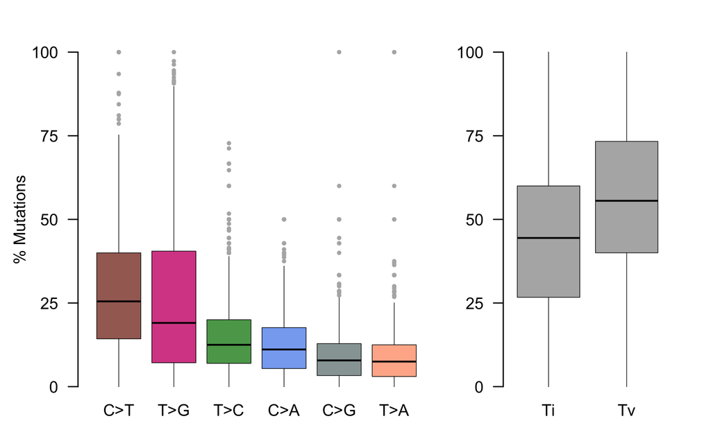

```r
maftools::plotTiTv(maftools::titv(strelka2, plot = FALSE), plotType = 'box')
```

#### MuTect2 transition/transversion plot.

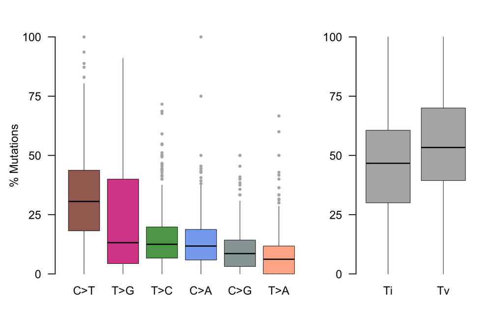

```r
maftools::plotTiTv(maftools::titv(mutect2, plot = FALSE), plotType = 'box')
```

## Compare number of variant calls per gene

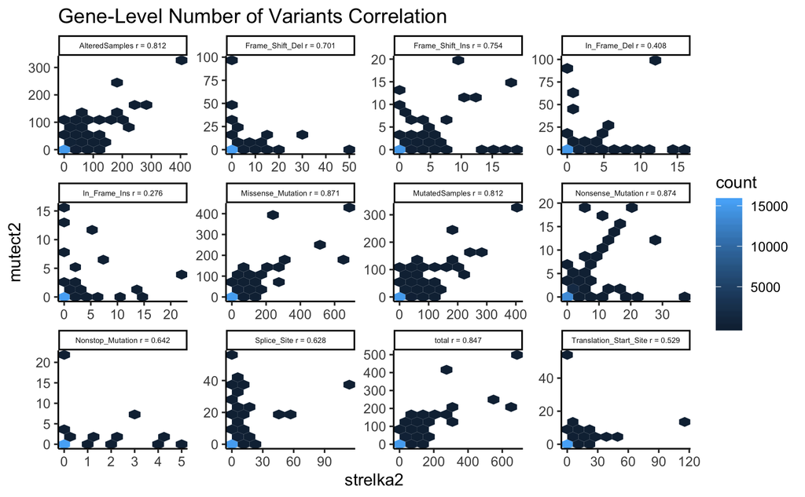

```r
# Correlate the gene summaries
correlate_maf_summaries(
  maf1 = strelka2,
  maf2 = mutect2,
  maf1_name = "strelka2",
  maf2_name = "mutect2",
  summarize_by = "gene",
  cor_method = "spearman",
  main_title = "Gene-Level Number of Variants Correlation"
)

# Save to a png
ggplot2::ggsave(file.path("plots", "gene_summary_cor_strelka-vs-mutect2.png"))
```

## Compare number of variant calls per sample

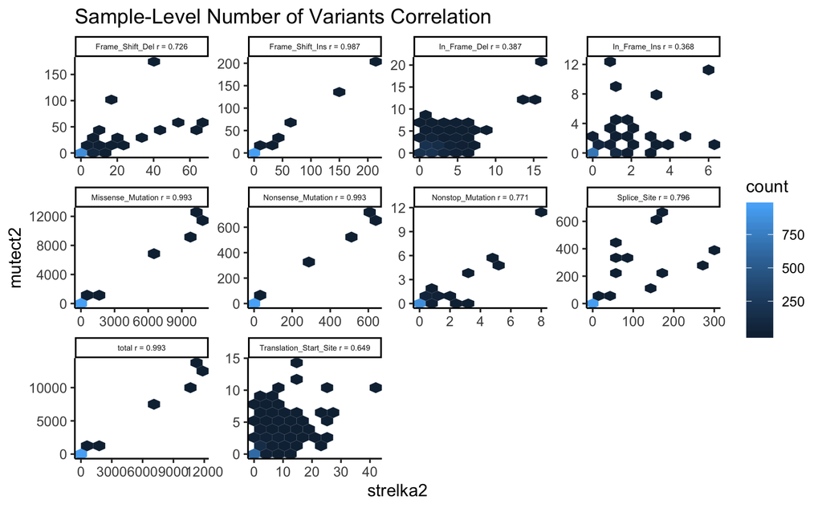

```r
# Correlate the sample summaries
correlate_maf_summaries(
  maf1 = strelka2,
  maf2 = mutect2,
  maf1_name = "strelka2",
  maf2_name = "mutect2",
  summarize_by = "sample",
  cor_method = "pearson",
  main_title = "Sample-Level Number of Variants Correlation"
)

# Save to a png
ggplot2::ggsave(file.path("plots", "sample_summary_cor_strelka-vs-mutect2.png"))
```

## Set up new variables

Let’s set up Strelka2’s variables first.

```r
# Use the premade function to create our new variables
strelka2_vaf <- set_up_variables(strelka2)
```

```
NAs introduced by coercion
```

```r
# Take a look at the new variables:
strelka2_vaf %>%
  dplyr::select(vaf, base_change, coding, change, mutation_id, PolyPhen_numeric,
                PolyPhen_category)
```

| vaf | base_change | coding | change | mutation_id | PolyPhen_numeric | PolyPhen_category |
| --- | --- | --- | --- | --- | --- | --- |
| 0.19444444 | C>T | protein_coding | C>T | SLC35E2A_C>T_1734736_BS_PJ08ZW9A | 0.477 | possibly_damaging |
| NA | GAG>- | protein_coding | deletion | DUSP27_deletion_167126161_BS_PJ08ZW9A | NA |  |
| 0.14666667 | T>G | protein_coding | T>G | RIF1_T>G_151457959_BS_PJ08ZW9A | 0.934 | probably_damaging |
| 0.15000000 | T>C | protein_coding | T>C | MUC4_T>C_195788612_BS_PJ08ZW9A | 0.224 | benign |
| 0.16071429 | A>C | protein_coding | A>C | TMEM63B_A>C_44152627_BS_PJ08ZW9A | 0.991 | probably_damaging |
| NA | GAG>- | protein_coding | deletion | ATXN7L1_deletion_105614355_BS_PJ08ZW9A | NA |  |
| 0.38775510 | G>A | protein_coding | G>A | EPHB6_G>A_142868665_BS_PJ08ZW9A | 0.999 | probably_damaging |
| 0.90625000 | C>T | protein_coding | C>T | OGA_C>T_101817872_BS_PJ08ZW9A | 0.000 | benign |
| NA | C>- | protein_coding | deletion | KMT2D_deletion_49037131_BS_PJ08ZW9A | NA |  |
| 0.46938776 | C>T | protein_coding | C>T | MAX_C>T_65078029_BS_PJ08ZW9A | 0.995 | probably_damaging |

[output cut: 990 more lines]

Now we will do the same for MuTect2.

```r
# Use the premade function to create our new variables
mutect2_vaf <- set_up_variables(mutect2)

# Take a look at the new variables
mutect2_vaf %>%
  dplyr::select(vaf, base_change, coding, change, mutation_id, PolyPhen_numeric,
                PolyPhen_category)
```

| vaf | base_change | coding | change | mutation_id | PolyPhen_numeric | PolyPhen_category |
| --- | --- | --- | --- | --- | --- | --- |
| 0.11111111 | GT>CA | protein_coding | long_change | NBPF10_long_change_146121575_BS_CHAFNK64 | 0.035 | benign |
| 0.10526316 | G>C | protein_coding | G>C | NBPF10_G>C_146121585_BS_CHAFNK64 | 0.579 | possibly_damaging |
| 0.11627907 | G>C | protein_coding | G>C | RGPD8_G>C_112370198_BS_CHAFNK64 | 0.000 | benign |
| 0.15625000 | T>C | protein_coding | T>C | MUC4_T>C_195782156_BS_CHAFNK64 | 0.224 | benign |
| 0.15151515 | CT>TC | protein_coding | long_change | MUC4_long_change_195782158_BS_CHAFNK64 | 0.220 | benign |
| 0.06315789 | G>C | protein_coding | G>C | ZDHHC11_G>C_840529_BS_CHAFNK64 | 0.014 | benign |
| 0.14285714 | A>C | protein_coding | A>C | PCDHB16_A>C_141184188_BS_CHAFNK64 | 0.000 | benign |
| 0.09876543 | TG>CC | protein_coding | long_change | METTL2B_long_change_128479325_BS_CHAFNK64 | 0.000 | benign |
| 0.10526316 | G>A | protein_coding | G>A | OTOGL_G>A_80265019_BS_CHAFNK64 | 1.000 | probably_damaging |
| 0.18750000 | T>C | protein_coding | T>C | AHNAK2_T>C_104945634_BS_CHAFNK64 | 0.028 | benign |

[output cut: 990 more lines]

## Combine MuTect2 and Strelka2 data.frames into one data.frame

Join these datasets based on the `mutation_id` created by the `set_up_variables` function. Save to a TSV file to be used in the subsequent notebook.

```r
# Merge these data.frames together
vaf_df <- strelka2_vaf %>%
  dplyr::full_join(mutect2_vaf,
    by = "mutation_id",
    suffix = c(".strelka2", ".mutect2")
  ) %>%
  # Make a variable that denotes which dataset it is in.
  dplyr::mutate(dataset = dplyr::case_when(
    is.na(Allele.mutect2) ~ "strelka2_only",
    is.na(Allele.strelka2) ~ "mutect2_only",
    TRUE ~ "both"
  )) %>%
  readr::write_tsv(file.path(results_dir, "combined_results.tsv"))
```

Make a zipped up version that can be stored on GitHub.

```r
zip(
  file.path(results_dir, "combined_results.tsv.zip"),
  file.path(results_dir, "combined_results.tsv")
)
```

```
updating: results/combined_results.tsv (deflated 85%)
```